# Part II - Ford GoBike Data Anlysis

## by Dane

## Investigation Overview

The overall goal of the analysis was to explore the differences & patterns in rides between the various attributes of the riders such as gender, year of birth, user type.

This presentation will explore:

- Basic information/analysis of the ridership from the dataset.
- Insights into Subscibers vs Customes ridership in terms of when they start their ride (hour of day, day of week) and differences in the duration of their ride.

## Dataset Overview

The data explored is the Ford GoBike data from San Francisco, California from February 1st to 28th, 2019. The data contains the following information about the riders:

- Memember information: gender, birth year, Subscriber or Customer (one time user).
- Ride information: duration, start station, end station, start and end times.
- Station information: station name, longitutde, latitude.

This analysis will focus on the difference in riding styles between Subscribers and Customers user types of the data set. Subscribers are riders who pay a monthly fee to rent the bikes and Customers do one time payment to ride.

## Ridership Breakdown

Let's take a look at some basics stats of the riders in the dataset. The following breaks down the riders in terms of gender, birth year, and user type.

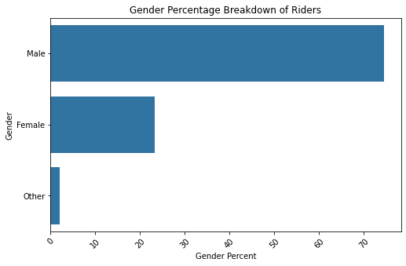

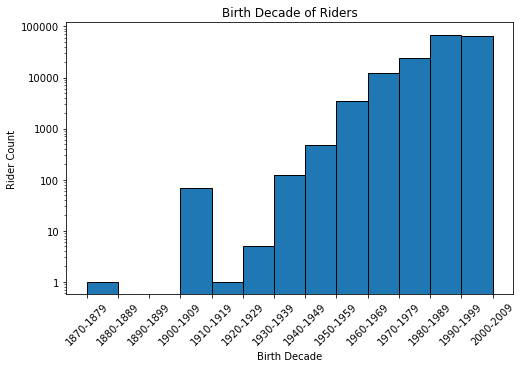

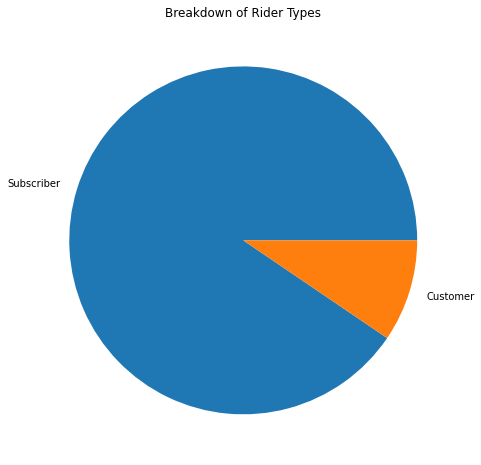

### Conclusions

The cursorary analysis revealed three aspects of the data:

- Most of the riders from the data set identify as male.
- Most of the riders are after 1980 and a few are set their birth year very low most likely to quickly get through the birth year prompt.
- Most of the riders are Subscribers and not Customers.

## How do Subscribers and Customers rent bikes differently?

Now that we have looked at a basic breakdown into the riders, let's take a look at how the rental styles of the two differ. Namely, is there a difference on which days and times they start their rentals?

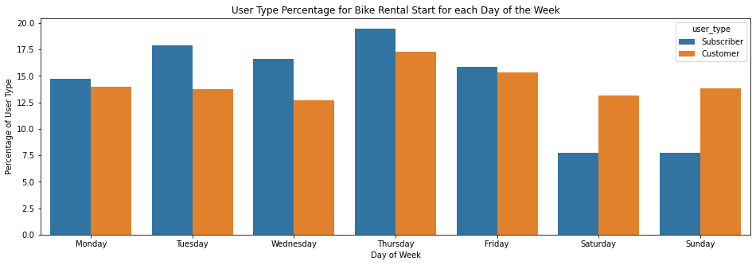

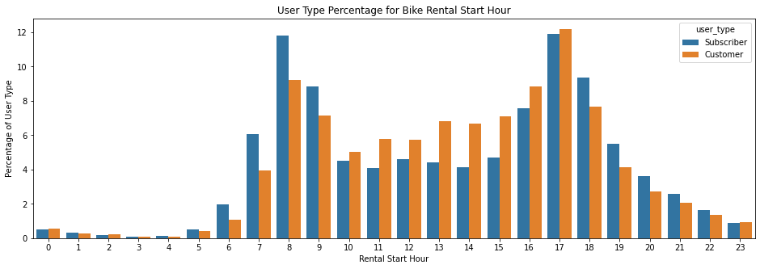

### Conclusions

Now that is certainly interesting! The percentage breakdown for users at their different start days and hours shows how each group tends to rent bikes. Namely, we can observe the following:

It seems like Subscribers tend to rent bikes around working hours: during the work week, and right before/after work. Customers are more likely to rent in the mornings and late afternoons as well but they rent more frequently throughout the day compared to Subscribers. This may mean that Subscribers are residents or people working in the area while Customers are likely to be people visiting and renting bikes as needed.

## Do Subscribers and Customers ride their bikes different durations?

It was interesting to see when the groups tended to rent their bikes. If Subscribers are residents, would they rent bikes for shorter duration for a commute? If Customers are visiting, do they tend to rent bikes for longer as they travel around the city?

Note: for ther est of the analysis, bikes over 4000s (~1.1 hours) were removed as they tended to be outliers in both groups.

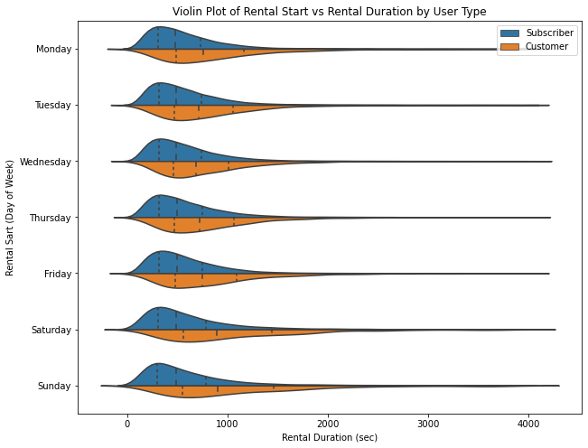

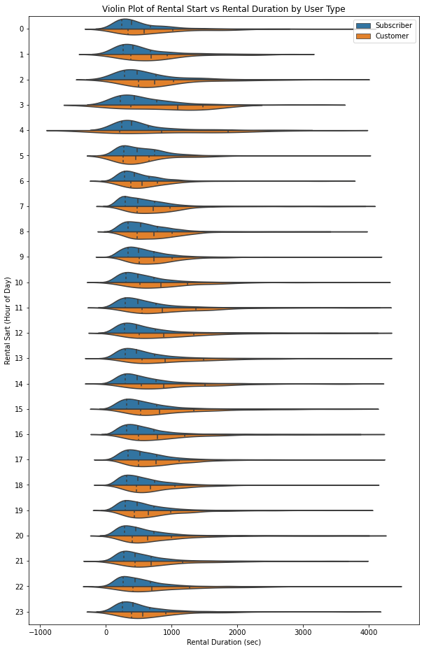

### Conclusions

Based on the above graphs, Customers tend to rent bikes for a little longer than Subscribers.